# Two-Way Manova: Eksperimen Rendaman Kulit Ikan

Diperoleh data hasil eksperimen rendaman kulit ikan dengan dua faktor (i.e. Konsentrasi dan Waktu perendaman garam alkali). Ingin diketahui apakah perlakuan tersebut berpengaruh/tidak terhadap dua variabel dependen sebagai output, yaitu Kandungan Lemak (**lemak**) dan Abu (**abu**) dari kulit ikan. Terdapat lima jenis Konsentrasi rendaman garam alkali (**konsentrasi**) yang digunakan sebagai percobaan, yaitu 0, 0.25, 0.50, 0.75, 1. Terdapat tiga jenis Waktu rendaman (**waktu**) yang digunakan sebagai percobaan, yaitu 30, 60, 90.

## (1) Library

Package yang dibutuhkan dalam keseluruhan analisis ini adalah:

```r
library(rstatix)
library(dplyr)
library(mvnormalTest)
library(heplots)
library(gridExtra)
library(gplots)
library(ggplot2)
library(effectsize)
library(GGally)
library(vegan)
library(readr)
library(formattable)
library(hrbrthemes)
library(viridis)
library(DiagrammeR)
library(MASS)
library(Rmisc)
```

## (2) Data dan Prosedur

Pengumpulan data dilakukan dengan dua kali repetisi. Hasil yang diperoleh sebagai berikut:

```r
data <- read_csv("data.csv")
formattable(data, align =c("c","c","c","c"), list(
  `konsentrasi`= formatter("span", style = ~ style(color = "grey",font.weight = "bold")),
  `waktu`= formatter("span", style = ~ style(color = "grey",font.weight = "bold")),
  `lemak`= color_tile("aquamarine", "aquamarine2"),
  `abu`= color_tile("lavenderblush", "lavenderblush2")
))
```

| konsentrasi | waktu | lemak | abu |
| --- | --- | --- | --- |
| 0.00 | 30 | 1.44 | 0.15 |
| 0.00 | 30 | 1.47 | 0.10 |
| 0.00 | 60 | 0.94 | 0.12 |
| 0.00 | 60 | 1.10 | 0.13 |
| 0.00 | 90 | 1.21 | 0.08 |
| 0.00 | 90 | 0.97 | 0.05 |
| 0.25 | 30 | 0.88 | 0.26 |
| 0.25 | 30 | 0.86 | 0.21 |
| 0.25 | 60 | 0.32 | 0.33 |
| 0.25 | 60 | 0.36 | 0.22 |
| 0.25 | 90 | 0.40 | 0.08 |
| 0.25 | 90 | 0.44 | 0.09 |
| 0.50 | 30 | 0.34 | 0.21 |
| 0.50 | 30 | 0.32 | 0.25 |
| 0.50 | 60 | 0.32 | 0.36 |
| 0.50 | 60 | 0.31 | 0.44 |
| 0.50 | 90 | 0.33 | 0.40 |
| 0.50 | 90 | 0.33 | 0.22 |
| 0.75 | 30 | 0.26 | 0.36 |
| 0.75 | 30 | 0.27 | 0.39 |
| 0.75 | 60 | 0.26 | 0.30 |
| 0.75 | 60 | 0.25 | 0.45 |
| 0.75 | 90 | 0.23 | 0.58 |
| 0.75 | 90 | 0.25 | 0.79 |
| 1.00 | 30 | 0.23 | 1.01 |
| 1.00 | 30 | 0.23 | 0.40 |
| 1.00 | 60 | 0.22 | 0.61 |
| 1.00 | 60 | 0.18 | 0.80 |
| 1.00 | 90 | 0.21 | 0.54 |
| 1.00 | 90 | 0.22 | 0.48 |

Untuk menguji hipotesis apakah faktor-faktor tersebut berpengaruh terhadap Kandungan Lemak dan Abu kulit ikan (dua variabel dependen) secara simultan, perlu dilakukan pengujian **Two-Way Manova**. Untuk melakukan pengujian ini, terlebih dahulu diilustrasikan langkah kerja sebagai berikut

```r
grViz("digraph flowchart {
      node [fontname = Helvetica, shape = oval, color = Lavender, style = filled]
      tab1 [label = '@@1', shape = plaintext, fillcolor = Beige]
      tab2 [label = '@@2', shape = plaintext, fillcolor = Beige]
      tab3 [label = '@@3']
      tab4 [label = '@@4', fillcolor = AquaMarine, shape = egg]
      tab5 [label = '@@5', fillcolor = Coral, shape = egg]
      tab6 [label = '@@6']
      tab7 [label = '@@7']
      tab8 [label = '@@8', fillcolor = LemonChiffon, shape = diamond]
      tab9 [label = '@@9', fillcolor = AquaMarine, shape = egg]
      tab10 [label = '@@10', fillcolor = Coral, shape = egg]
      tab11 [label = '@@11']
      tab12 [label = '@@12', shape = square, fillcolor = Beige]

      # edge definitions with the node IDs
      tab1 -> tab2
      tab2 -> tab3
      tab3 -> tab4 -> tab6
      tab3 -> tab5 -> tab7
      tab6 -> tab8 -> tab9
      tab7 -> tab8 -> tab10
      tab9 -> tab11 -> tab12
      tab10 -> tab12
      }

      [1]: 'Data Eksperimen'
      [2]: 'Visualisasi dan Deskripsi Data'
      [3]: '#1 Uji Asumsi Manova'
      [4]: 'Layak'
      [5]: 'Tidak'
      [6]: '#2 General Manova'
      [7]: '#2 Robust Manova'
      [8]: 'Signifikan?'
      [9]: 'Ya'
      [10]: 'Tidak'
      [11]: '#3 Post-Hoc Test'
      [12]: 'End'
      ")
```

[interactive chart not shown]

## (3) Deskripsi dan Visualisasi Data

Langkah selanjutnya adalah mendeskripsikan dan memvisualisasikan data sehingga memberikan gambaran secara umum tentang pengamatan yang diperoleh.

```r
data$konsentrasi <- as.factor(data$konsentrasi)
data$waktu <- as.factor(data$waktu)

# deskripsi variabel Lemak berdasarkan faktor
data %>% group_by(waktu) %>%  summarise(n = n(), mean = mean(lemak), sd = sd(lemak))
```

| waktu | n | mean | sd |
| --- | --- | --- | --- |
| 30 | 10 | 0.630 | 0.4993106 |
| 60 | 10 | 0.426 | 0.3197638 |
| 90 | 10 | 0.459 | 0.3460074 |

```r
data %>% group_by(konsentrasi) %>%  summarise(n = n(), mean = mean(lemak), sd = sd(lemak))
```

| konsentrasi | n | mean | sd |
| --- | --- | --- | --- |
| 0 | 6 | 1.1883333 | 0.22815930 |
| 0.25 | 6 | 0.5433333 | 0.25625508 |
| 0.5 | 6 | 0.3250000 | 0.01048809 |
| 0.75 | 6 | 0.2533333 | 0.01366260 |
| 1 | 6 | 0.2150000 | 0.01870829 |

```r
# deskripsi variabel Abu berdasarkan faktor
data %>% group_by(waktu) %>%  summarise(n = n(), mean = mean(abu), sd = sd(abu))
```

| waktu | n | mean | sd |
| --- | --- | --- | --- |
| 30 | 10 | 0.334 | 0.2575612 |
| 60 | 10 | 0.376 | 0.2115131 |
| 90 | 10 | 0.331 | 0.2621895 |

```r
data %>% group_by(konsentrasi) %>%  summarise(n = n(), mean = mean(abu), sd = sd(abu))
```

| konsentrasi | n | mean | sd |
| --- | --- | --- | --- |
| 0 | 6 | 0.1050000 | 0.03619392 |
| 0.25 | 6 | 0.1983333 | 0.09745084 |
| 0.5 | 6 | 0.3133333 | 0.09912954 |
| 0.75 | 6 | 0.4783333 | 0.17993517 |
| 1 | 6 | 0.6400000 | 0.22653918 |

```r
NA
```

Selanjutnya disajikan Violin + Box Plot sebagai gambaran sebaran data

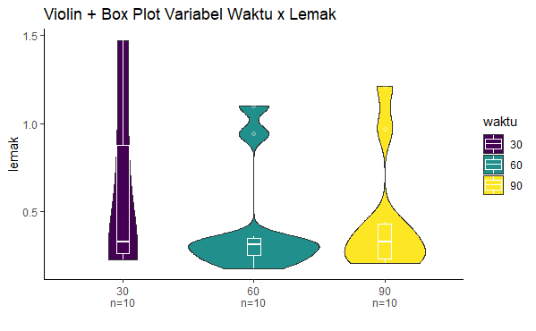

```r
# Viloin + Box Plot by faktor waktu

sample_waktu = data %>% group_by(waktu) %>% summarize(num=n())

data %>%
  left_join(sample_waktu) %>%
  mutate(myaxis = paste0(waktu, "\n", "n=", num)) %>%
  ggplot(aes(x=myaxis, y=lemak, fill=waktu)) +
  geom_violin(width=1) +
  geom_boxplot(width=0.1, color="white", alpha=0.2) +
  scale_fill_viridis(discrete = T, option = "D") +
  theme( legend.position="none", plot.title = element_text(size=11)) +
  ggtitle("Violin + Box Plot Variabel Waktu x Lemak") +
  xlab("") + theme_classic()
```

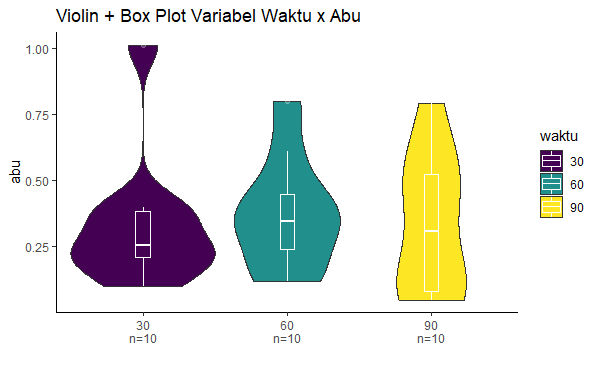

```r
data %>%
  left_join(sample_waktu) %>%
  mutate(myaxis = paste0(waktu, "\n", "n=", num)) %>%
  ggplot(aes(x=myaxis, y=abu, fill=waktu)) +
  geom_violin(width=1) +
  geom_boxplot(width=0.1, color="white", alpha=0.2) +
  scale_fill_viridis(discrete = T, option = "D") +
  theme( legend.position="none", plot.title = element_text(size=11)) +
  ggtitle("Violin + Box Plot Variabel Waktu x Abu") +
  xlab("") + theme_classic()
```

Dari gambar pertama (Waktu x Lemak), dapat dilihat bahwa tidak terlalu tampak perbedaan sebaran data output Lemak pada tiga kondisi berbeda. Pun juga dengan (Abu x Lemak) yang menggambarkan pola dan distribusi yang serupa.

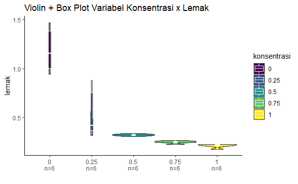

```r
# Viloin + Box Plot by faktor konsentrasi

sample_konsen = data %>% group_by(konsentrasi) %>% summarize(num=n())
data %>%
  left_join(sample_konsen) %>%
  mutate(myaxis = paste0(konsentrasi, "\n", "n=", num)) %>%
  ggplot(aes(x=myaxis, y=lemak, fill=konsentrasi)) +
  geom_violin(width=1) +
  geom_boxplot(width=0.1, color="white", alpha=0.2) +
  scale_fill_viridis(discrete = T, option = "D") +
  theme( legend.position="none", plot.title = element_text(size=11)) +
  ggtitle("Violin + Box Plot Variabel Konsentrasi x Lemak") +
  xlab("") + theme_classic()
```

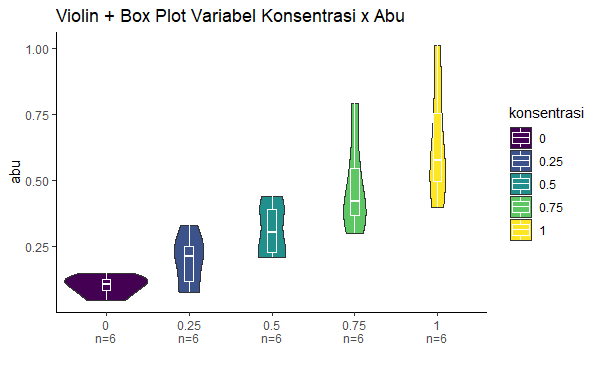

```r
data %>%
  left_join(sample_konsen) %>%
  mutate(myaxis = paste0(konsentrasi, "\n", "n=", num)) %>%
  ggplot(aes(x=myaxis, y=abu, fill=konsentrasi)) +
  geom_violin(width=1) +
  geom_boxplot(width=0.1, color="white", alpha=0.2) +
  scale_fill_viridis(discrete = T, option = "D") +
  theme( legend.position="none", plot.title = element_text(size=11)) +
  ggtitle("Violin + Box Plot Variabel Konsentrasi x Abu") +
  xlab("") + theme_classic()
```

Tidak seperti pada faktor Waktu, faktor Konsentrasi lebih tampak memiliki perbedaan secara visual seiring perbedaan kadar Konsentrasi larutan.

## (4) Pengujian Asumsi Manova

Model Manova dibangun berdasarkan beberapa asumsi. Beberapa yang utama adalah:

1. *Multivariate Normality*; variabel dependen berdistribusi normal secara bersamaan pada setiap faktor
2. *Homogenitas Varians*; varians dalam populasi faktor seragam
3. *No Multivariate Outliers*; pengamatan yang menyebar signifikan berbeda dibandingkan dengan sebaran data pada umumnya
4. *Non Multicolinearity*; tidak terjadi korelasi yang tinggi pada antar variabel dependen
5. *Linearity*; terdapat pola cenderung linear antar variabel dependen dalam faktor

Sebelum melakukan pengujian Manova secara umum, seluruh asumsi tersebut haruslah dipenuhi. Seluruh asumsi tersebut memang cenderung lebih ‘mudah’ terpenuhi ketika data yang diperoleh relatif cukup besar (i.e. >50 data).

### (4.1) Multivariate Normality

Pengujian asumsi normalitas multivariat dilakukan terhadap variabel dependen dengan melihat skewness, kurtosis, dan multivariat normality. Dengan menggunakan Mardia’s Test, pengujian dilakukan sebagai berikut

```r
mardia(data[, c("lemak", "abu")])$mv.test
```

| Test | Statistic | p-value | Result |
| --- | --- | --- | --- |
| Skewness | 18.3191 | 0.0011 | NO |
| Kurtosis | 0.9685 | 0.3328 | YES |
| MV Normality | NA | NA | NO |

```r
NA
```

Dari hasil tersebut, p-value pada kurtosis non signifikan (p > 0.05) namun pada skewness signifikan (p < 0.05). Oleh karena itu **hipotesis nol bahwa terdapat normalitas multivariat pada data ini ditolak**. Hal ini menandakan bahwa terdapat masalah pada normalitas multivariat. Ketidaknormalan multivariat yang terjadi dapat dipahami karena beberapa hal, seperti jumlah sampel yang relatif sedikit dan efek tes faktor yang mungkin memberikan hasil yang sangat berbeda.

### (4.2) Homogenitas Varians

Homogenitas varians diuji menggunakan tes Box-M pada variabel dependen untuk masing-masing faktor.

```r
boxM(cbind(lemak, abu) ~ konsentrasi, data = data)
```

```
    Box's M-test for Homogeneity of Covariance Matrices

data:  Y
Chi-Sq (approx.) = 69.089, df = 12, p-value = 4.741e-10
```

```r
boxM(cbind(lemak, abu) ~ waktu, data = data)
```

```
    Box's M-test for Homogeneity of Covariance Matrices

data:  Y
Chi-Sq (approx.) = 4.1668, df = 6, p-value = 0.6541
```

Hasil Box’s M-test menunjukkan bahwa variabel dependen berdasarkan faktor Konsentrasi signifikan (p < 0.05) sedangkan berdasarkan faktor Waktu non signifikan (p > 0.05). Berdasarkan hasil tersebut, dapat disimpulkan bahwa pada variabel dependen memiliki matriks covariance yang homogen di dalam faktor waktu dan cenderung tidak memiliki matriks covariance yang tidak homogen di dalam faktor Konsentrasi. Walaupun demikian, Box’s M-test memiliki ‘kelemahan’ akurasi pada sampel dengan pengamatan yang kecil.

Sebagai komplementari atas Box’s M-test, dilakukan pengujian yang hampir serupa dengan menggunakan Bartlett Test khusus untuk faktor Konsentrasi.

```r
bartlettTests(data[,3:4], data$konsentrasi)
```

```
Bartlett's Tests for Homogeneity of Variance

       Chisq df Pr(>Chisq)
lemak 58.428  4  6.204e-12 ***
abu   13.745  4   0.008153 **
---
Signif. codes:  0 ‘***’ 0.001 ‘**’ 0.01 ‘*’ 0.05 ‘.’ 0.1 ‘ ’ 1
```

Hasilnya memang kedua variabel (Lemak dan Abu) memang cenderung tidak memiliki varians yang homogen pada faktor Konsentrasi (p < 0.05)

### (4.3) No Multivariat Outlier

Untuk menguji outlier secara multivariat dapat menggunakan parameter pengujian Mahalanobis Distance sebagai berikut

```r
mahalanobis_distance(data = data[, c("lemak", "abu")])$is.outlier
```

```
 [1] FALSE FALSE FALSE FALSE FALSE FALSE FALSE FALSE FALSE FALSE FALSE FALSE FALSE
[14] FALSE FALSE FALSE FALSE FALSE FALSE FALSE FALSE FALSE FALSE FALSE FALSE FALSE
[27] FALSE FALSE FALSE FALSE
```

Dari hasil tersebut, seluruh pengamatan bukan merupakan multivariat outlier (seluruh `is.outlier` = FALSE menandakan p > 0.05)

### (4.4) Non Multicolinearity

Pengujian non multikolinearitas dapat dilakukan dengan menggunakan korelasi antar variabel dependen

```r
data %>% cor_test (lemak, abu)
```

| var1 | var2 | cor | statistic | p | conf.low | conf.high | method |
| --- | --- | --- | --- | --- | --- | --- | --- |
| lemak | abu | -0.62 | -4.187664 | 0.000254 | -0.8016202 | -0.3352565 | Pearson |

Hasil korelasi Pearson menunjukkan nilai (-0.62) yang dapat disimpulkan bahwa tidak terjadi multikolinearitas (hasil korelasi kurang dari {+/-} 0.80 sebagai batas korelasi tinggi)

### (4.5) Linearitas

Menguji linearitas pada data sampel yang relatif kecil memang agak sulit dilihat. Walaupun demikian kita tetap dapat membuat Scatter Plot dari variabel dependen berdasarkan faktor sebagai berikut

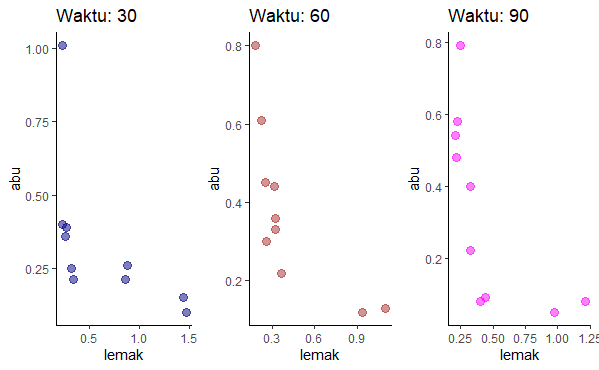

```r
# berdasarkan faktor waktu
c1 <- data  %>% group_by(waktu) %>%
  filter(waktu == "30") %>%
  ggplot(aes(x = lemak, y = abu)) +
  geom_point(color="navy", shape=20, alpha=0.5, size=4, stroke = 1) +
  ggtitle("Waktu: 30") + theme_classic()

c2 <- data  %>% group_by(waktu) %>%
  filter(waktu == "60") %>%
  ggplot(aes(x = lemak, y = abu)) +
  geom_point(color="brown", shape=20, alpha=0.5, size=4, stroke = 1) +
  ggtitle("Waktu: 60") + theme_classic()

c3 <- data  %>% group_by(waktu) %>%
  filter(waktu == "90") %>%
  ggplot(aes(x = lemak, y = abu)) +
  geom_point(color="magenta", shape=20, alpha=0.5, size=4, stroke = 1) +
  ggtitle("Waktu: 90") + theme_classic ()

grid.arrange(c1, c2, c3, ncol=3)
```

Dengan data yang relatif sedikit, belum menggambarkan pola ‘linear’ yang terlihat.

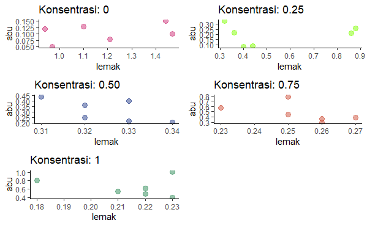

```r
# berdasarkan faktor konsentrasi
c4 <- data  %>% group_by(konsentrasi) %>%
  filter(konsentrasi == "0") %>%
  ggplot(aes(x = lemak, y = abu)) +
  geom_point(color="violetred3", shape=20, alpha=0.5, size=4, stroke = 1) +
  ggtitle("Konsentrasi: 0") + theme_classic()

c5 <- data  %>% group_by(konsentrasi) %>%
  filter(konsentrasi == "0.25") %>%
  ggplot(aes(x = lemak, y = abu)) +
  geom_point(color="chartreuse1", shape=20, alpha=0.5, size=4, stroke = 1) +
  ggtitle("Konsentrasi: 0.25") + theme_classic()

c6 <- data  %>% group_by(konsentrasi) %>%
  filter(konsentrasi == "0.5") %>%
  ggplot(aes(x = lemak, y = abu)) +
  geom_point(color="royalblue4", shape=20, alpha=0.5, size=4, stroke = 1) +
  ggtitle("Konsentrasi: 0.50") + theme_classic()

c7 <- data  %>% group_by(konsentrasi) %>%
  filter(konsentrasi == "0.75") %>%
  ggplot(aes(x = lemak, y = abu)) +
  geom_point(color="tomato3", shape=20, alpha=0.5, size=4, stroke = 1) +
  ggtitle("Konsentrasi: 0.75") + theme_classic()

c8 <- data  %>% group_by(konsentrasi) %>%
  filter(konsentrasi == "1") %>%
  ggplot(aes(x = lemak, y = abu)) +
  geom_point(color="seagreen4", shape=20, alpha=0.5, size=4, stroke = 1) +
  ggtitle("Konsentrasi: 1") + theme_classic()

grid.arrange(c4, c5, c6, c7, c8, ncol=2)
```

dari seluruh Scatter Plot tersebut dan dengan pengamatan yang terbatas, kita belum bisa memutuskan apakah terdapat pola yang linear dalam data.

Secara keseluruhan, dari lima pengujian asumsi yang sudah dilakukan dapat disimpulkan sebagai berikut

```r
tabel_asumsi <- data.frame(Asumsi=c('Normalitas Multivariat',
                                    'Homogenitas Varians',
                                    'No Multivariate Outlier',
                                    'Non Multicolinearity',
                                    'Linearity'),
                 Terpenuhi=c('No',
                              'No',
                              'Yes',
                             'Yes',
                             'n.a'),  stringsAsFactors = F)

formattable(tabel_asumsi,
            align = c("l","c"),
            list(`Asumsi` = formatter("span", style = ~ style(color = "grey")),
                 `Terpenuhi` = formatter("span", style = ~ style(color = "grey"))))
```

| Asumsi | Terpenuhi |
| --- | --- |
| Normalitas Multivariat | No |
| Homogenitas Varians | No |
| No Multivariate Outlier | Yes |
| Non Multicolinearity | Yes |
| Linearity | n.a |

```r
NA
```

Dari kelima asumsi dalam Manova, hanya dua yang terpenuhi yaitu aspek No Multivariate Outlier dan Non Multicollinearity. Untuk melanjutkan ke analisis Manova, ada dua skenario dapat dilakukan, yaitu tetap melanjutkan dengan analisis Manova secara umum (dengan mengabaikan temuan bahwa beberapa asumsi tidak terpenuhi) atau menggunakan Robust Manova (metode non parametrik yang mengakomodasi ketika ada asumsi yang tidak terpenuhi). Sebagai bahan perbandingan, kedua analisis tersebut dilakukan.

## (5) Analisis Manova

### (5.1) Manova Umum

Kita melanjutkan analisis dengan Manova umum seperti biasa walaupun beberapa asumsi tidak terpenuhi. Model pengujiannya sebagai berikut

```r
amatan <- cbind(data$lemak, data$abu)
manova.umum <- manova(amatan ~ waktu + konsentrasi, data = data)
summary(manova.umum)
```

```
            Df  Pillai approx F num Df den Df    Pr(>F)
waktu        2 0.43427   3.1896      4     46   0.02151 *
konsentrasi  4 1.30196  10.7247      8     46 2.347e-08 ***
Residuals   23
---
Signif. codes:  0 ‘***’ 0.001 ‘**’ 0.01 ‘*’ 0.05 ‘.’ 0.1 ‘ ’ 1
```

Dari hasil tersebut dapat dilihat bahwa faktor waktu dan konsentrasi memiliki hasil yang signifikan (faktor waktu:: Pillai = 0.434, F = 3.18, p < 0.05) (faktor konsentrasi:: Pillai = 1.301, F = 10.72, p < 0.05) terhadap kandungan lemak dan abu secara simultan. **Kesimpulan: Dengan demikian, dengan derajat kepercayaan 95%, data mendukung pendapat bahwa faktor perlakuan (Waktu dan Konsentrasi Rendaman Alkali) memberikan pengaruh signifikan terhadap Kandungan Lemak dan Abu Kulit Ikan.**

### (5.2) Robust Manova

Manova Robust digunakan ketika beberapa asumsi tidak terpenuhi. Analisis ini adalah non-parametrik untuk Manova model. Terdapat beberapa metode estimasi yang digunakan ketika asumsi Manova tidak terpenuhi. Salah satunya dengan menggunakan `adonis` function dengan pendekatan metode mahalanobis untuk menghitung jarak antar pengamatannya.

```r
manova.robust <- adonis(formula = amatan ~ konsentrasi + waktu, data = data,
       permutations = 500, method = "mahalanobis")
manova.robust
```

```
Call:
adonis(formula = amatan ~ konsentrasi + waktu, data = data, permutations = 500,      method = "mahalanobis")

Permutation: free
Number of permutations: 500

Terms added sequentially (first to last)

            Df SumsOfSqs MeanSqs F.Model      R2   Pr(>F)
konsentrasi  4    36.245  9.0613 10.6585 0.62492 0.001996 **
waktu        2     2.201  1.1007  1.2948 0.03796 0.297405
Residuals   23    19.553  0.8501         0.33713
Total       29    58.000                 1.00000
---
Signif. codes:  0 ‘***’ 0.001 ‘**’ 0.01 ‘*’ 0.05 ‘.’ 0.1 ‘ ’ 1
```

Metode Robust Manova ternyata memberikan hasil signifikansi yang berbeda dibandingkan dengan Manova umum. Faktor Konsentrasi signifikan terhadap variabel dependen (F.Model = 10.65, p < 0.05) , sedangkan faktor Waktu tidak signifikan terhadap variabel dependen (F.Model = 1.29, p > 0.05). **Kesimpulan: Dengan menggunakan metode estimasi Robust Manova dan dengan derajat kepercayaan 95%, data mendukung pendapat bahwa faktor Konsentrasi Rendaman Alkali memberikan pengaruh signifikan terhadap kandungan Lemak dan Abu kulit ikan. Sedangkan faktor Waktu rendaman tidak signifikan terhadap kandungan Lemak dan Abu kulit ikan.**

## (6) Post-Hoc Test

Walaupun tidak memberikan hasil yang seragam, baik Manova dan Robust Manova tetap memberikan adanya hasil yang signifikan antara variabel dependen dan faktor perlakuannya. Oleh karena itu, kita perlu meneruskan ke pengujian lanjutan (post-hoc test) untuk mengetahui dari faktor yang signifikan tersebut, perlakuan mana yang memberikan hasil berbeda terhadap output (variabel dependen). Metode analisis lanjutan ini akan dibagi berdasarkan dua pengujian Manova yang dilakukan

Terdapat beberapa referensi metode dalam melakukan post-hoc test pada Manova. Beberapa diantaranya adalah: * Univariat Anova, Tukey HSD, Bonferroni, dan Scheffe Test (untuk metode Manova secara umum) *[1]* *[2]* *[3]* *[4]*

- Bonferroni dan Games Howell Test (untuk metode Robust Manova) *[5]*
- Discriminant Analysis *[6]*

### (6.1) Uji Lanjutan Manova Umum

Untuk pengujian lanjutan Manova umum digunakan dua metode uji lanjutan, yaitu univariat anova dan Tukey HSD. Effectsize test juga dilakukan untuk melihat faktor mana yang memberikan efek paling besar terhadap kandungan Lemak dan Abu.

#### (6.1.1) Univariate Anova

Pengujian ini pada dasarnya adalah pengujian two-way anova

```r
summary.aov(manova.umum)
```

```
 Response 1 :
            Df Sum Sq Mean Sq F value    Pr(>F)
waktu        2 0.2398 0.11991  7.8344  0.002542 **
konsentrasi  4 3.8895 0.97238 63.5305 4.281e-12 ***
Residuals   23 0.3520 0.01531
---
Signif. codes:  0 ‘***’ 0.001 ‘**’ 0.01 ‘*’ 0.05 ‘.’ 0.1 ‘ ’ 1

 Response 2 :
            Df  Sum Sq Mean Sq F value    Pr(>F)
waktu        2 0.01266 0.00633   0.286    0.7539
konsentrasi  4 1.10938 0.27735  12.533 1.484e-05 ***
Residuals   23 0.50899 0.02213
---
Signif. codes:  0 ‘***’ 0.001 ‘**’ 0.01 ‘*’ 0.05 ‘.’ 0.1 ‘ ’ 1
```

Hasil tersebut serupa dengan apabila kita menjalankan two-way anova pada masing-masing variabel dependen. Response 1 menandakan variabel Lemak sedangkan Response 2 menandakan variabel Abu. Dari univariat anova dapat dilihat bahwa faktor Waktu dan Konsentrasi signifikan berpengaruh terhadap Kandungan Lemak. Sedangkan pada Kandungan Abu, hanya faktor konsentrasi yang signifikan berpengaruh.

#### (6.1.2) Tukey HSD

Untuk pengujian Tukey HSD, kita terlebih dahulu membentuk masing-masing two-way anova. Model two way anova ini akan sama persis dengan uji univariat anova pada bagian Manova.

```r
# model 1:lemak
an.lemak <- aov(lemak ~ konsentrasi + waktu, data = data)
TukeyHSD(an.lemak)
```

```
  Tukey multiple comparisons of means
    95% family-wise confidence level

Fit: aov(formula = lemak ~ konsentrasi + waktu, data = data)

$konsentrasi
                 diff        lwr          upr     p adj
0.25-0    -0.64500000 -0.8561414 -0.433858632 0.0000000
0.5-0     -0.86333333 -1.0744747 -0.652191965 0.0000000
0.75-0    -0.93500000 -1.1461414 -0.723858632 0.0000000
1-0       -0.97333333 -1.1844747 -0.762191965 0.0000000
0.5-0.25  -0.21833333 -0.4294747 -0.007191965 0.0402928
0.75-0.25 -0.29000000 -0.5011414 -0.078858632 0.0040028
1-0.25    -0.32833333 -0.5394747 -0.117191965 0.0010939
0.75-0.5  -0.07166667 -0.2828080  0.139474701 0.8511418
1-0.5     -0.11000000 -0.3211414  0.101141368 0.5483603
1-0.75    -0.03833333 -0.2494747  0.172808035 0.9825013

$waktu
        diff        lwr         upr     p adj
60-30 -0.204 -0.3425586 -0.06544138 0.0033620
90-30 -0.171 -0.3095586 -0.03244138 0.0137525
90-60  0.033 -0.1055586  0.17155862 0.8233879
```

Pada pengujian variabel Lemak, perbedaan faktor Konsentrasi dan Waktu memberikan efek yang berbeda apabila:

| Konsentrasi | Waktu |
| --- | --- |
| Seluruh konsentrasi pengujian vs Konsentrasi 0 | Seluruh waktu pengujian vs waktu 30 |
| Seluruh konsentrasi pengujian vs Konsentrasi 0.25 |  |

Adapun perbandingan output Lemak pada perbandingan Konsentrasi > 0.25 tidak memberikan efek signifikan. Pun juga perbandingan Waktu yang tidak dibandingkan dengan level 30 tidak memberikan efek signifikan.

```r
# model 2:abu
an.abu <- aov(abu ~ konsentrasi + waktu, data = data)
TukeyHSD(an.abu)
```

```
  Tukey multiple comparisons of means
    95% family-wise confidence level

Fit: aov(formula = abu ~ konsentrasi + waktu, data = data)

$konsentrasi
                diff         lwr       upr     p adj
0.25-0    0.09333333 -0.16055230 0.3472190 0.8114573
0.5-0     0.20833333 -0.04555230 0.4622190 0.1441268
0.75-0    0.37333333  0.11944770 0.6272190 0.0020063
1-0       0.53500000  0.28111437 0.7888856 0.0000215
0.5-0.25  0.11500000 -0.13888563 0.3688856 0.6706483
0.75-0.25 0.28000000  0.02611437 0.5338856 0.0257625
1-0.25    0.44166667  0.18778104 0.6955523 0.0002902
0.75-0.5  0.16500000 -0.08888563 0.4188856 0.3348084
1-0.5     0.32666667  0.07278104 0.5805523 0.0073709
1-0.75    0.16166667 -0.09221896 0.4155523 0.3542523

$waktu
        diff       lwr      upr     p adj
60-30  0.042 -0.124609 0.208609 0.8045527
90-30 -0.003 -0.169609 0.163609 0.9988796
90-60 -0.045 -0.211609 0.121609 0.7793717
```

Pada pengujian variabel Abu, perbedaan faktor Konsentrasi dan Waktu memberikan efek yang berbeda apabila:

| Konsentrasi | Waktu |
| --- | --- |
| Perbandingan 0.75 : 0.00 | Tidak ada |
| Perbandingan 1.00 : 0.00 |  |
| Perbandingan 0.75 : 0.25 |  |
| Perbandingan 1.00 : 0.25 |  |
| Perbandingan 1.00 : 0.50 |  |

Hanya lima perbandingan dengan ‘gap’ konsentrasi >=0.5 yang signifikan terhadap kadar Abu. Sedangkan pada faktor waktu, tidak memberikan efek yang signifikan terhadap kadar Abu.

> Pada uji lanjutan Manova umum, baik univariat Anova maupun Tukey HSD memberikan hasil yang seragam.

#### (6.1.3) Effect Size Test

```r
## effect size
eta_squared(manova.umum)
```

```
# Effect Size for ANOVA (Type I)

Parameter   | Eta2 (partial) |       95% CI
-------------------------------------------
waktu       |           0.22 | [0.02, 1.00]
konsentrasi |           0.65 | [0.48, 1.00]

- One-sided CIs: upper bound fixed at (1).
```

Dari hasil pengujian effect size tersebut, dapat dilihat bahwa faktor Konsentrasi (eta<sup>2</sup> partial = 0.65) memberikan efek yang lebih besar terhadap variabel dependen dibandingkan dengan Waktu (eta<sup>2</sup> partial = 0.22).

### (6.2) Uji Lanjutan Robust Manova

Untuk pengujian lanjutan Robust Manova digunakan dua metode uji, yaitu Pairwise Comparison Bonferroni dan Games Howell Test.

#### (6.2.1) Bonferroni Test

Karena terdapat beberapa asumsi yang tidak terpenuhi, Pairwise comparison dilakukan dengan sedikit penyesuaian pada tidak terpenuhinya asumsi homogenitas varians (yaitu dengan setting fitur `var.equal` = FALSE)

```r
# variabel Kandungan Lemak
pairwise_t_test(data = data, formula = lemak ~ waktu, pool.sd = F,
                var.equal = F)
```

|  | .y. | group1 | group2 | n1 | n2 | statistic | df | p | p.adj | p.adj.signif |
| --- | --- | --- | --- | --- | --- | --- | --- | --- | --- | --- |
| 1 | lemak | 30 | 60 | 10 | 10 | 1.0880039 | 15.31933 | 0.293 | 0.879 | ns |
| 2 | lemak | 30 | 90 | 10 | 10 | 0.8901516 | 16.02401 | 0.387 | 0.879 | ns |
| 3 | lemak | 60 | 90 | 10 | 10 | -0.2214965 | 17.88916 | 0.827 | 0.879 | ns |

```r
pairwise_t_test(data = data, formula = lemak ~ konsentrasi, pool.sd = F,
                var.equal = F)
```

|  | .y. | group1 | group2 | n1 | n2 | statistic | df | p | p.adj | p.adj.signif |
| --- | --- | --- | --- | --- | --- | --- | --- | --- | --- | --- |
| 1 | lemak | 0 | 0.25 | 6 | 6 | 4.604729 | 9.868106 | 1.00e-03 | 5.00e-03 | ** |
| 2 | lemak | 0 | 0.5 | 6 | 6 | 9.258862 | 5.021131 | 2.42e-04 | 1.00e-03 | ** |
| 3 | lemak | 0 | 0.75 | 6 | 6 | 10.020094 | 5.035858 | 1.63e-04 | 1.00e-03 | ** |
| 4 | lemak | 0 | 1 | 6 | 6 | 10.414633 | 5.067231 | 1.30e-04 | 1.00e-03 | ** |
| 5 | lemak | 0.25 | 0.5 | 6 | 6 | 2.085258 | 5.016751 | 9.10e-02 | 9.10e-02 | ns |
| 6 | lemak | 0.25 | 0.75 | 6 | 6 | 2.768119 | 5.028426 | 3.90e-02 | 7.80e-02 | ns |
| 7 | lemak | 0.25 | 1 | 6 | 6 | 3.130140 | 5.053298 | 2.60e-02 | 7.70e-02 | ns |
| 8 | lemak | 0.5 | 0.75 | 6 | 6 | 10.191977 | 9.373964 | 2.23e-06 | 2.01e-05 | **** |
| 9 | lemak | 0.5 | 1 | 6 | 6 | 12.562885 | 7.860327 | 1.76e-06 | 1.76e-05 | **** |
| 10 | lemak | 0.75 | 1 | 6 | 6 | 4.053217 | 9.152249 | 3.00e-03 | 1.10e-02 | * |

```r
NA
```

Pada pengujian variabel Lemak, perbedaan faktor Konsentrasi dan Waktu memberikan efek yang berbeda apabila:

[output not shown]

```r
# variabel Kandungan Abu
pairwise_t_test(data = data, formula = abu ~ waktu, pool.sd = F,
                var.equal = F)
```

|  | .y. | group1 | group2 | n1 | n2 | statistic | df | p | p.adj | p.adj.signif |
| --- | --- | --- | --- | --- | --- | --- | --- | --- | --- | --- |
| 1 | abu | 30 | 60 | 10 | 10 | -0.39851075 | 17.34412 | 0.695 | 1 | ns |
| 2 | abu | 30 | 90 | 10 | 10 | 0.02581214 | 17.99429 | 0.980 | 1 | ns |
| 3 | abu | 60 | 90 | 10 | 10 | 0.42242608 | 17.22903 | 0.678 | 1 | ns |

```r
pairwise_t_test(data = data, formula = abu ~ konsentrasi, pool.sd = F,
                var.equal = F)
```

|  | .y. | group1 | group2 | n1 | n2 | statistic | df | p | p.adj | p.adj.signif |
| --- | --- | --- | --- | --- | --- | --- | --- | --- | --- | --- |
| 1 | abu | 0 | 0.25 | 6 | 6 | -2.199209 | 6.353673 | 0.068 | 0.271 | ns |
| 2 | abu | 0 | 0.5 | 6 | 6 | -4.835671 | 6.309829 | 0.003 | 0.023 | * |
| 3 | abu | 0 | 0.75 | 6 | 6 | -4.982455 | 5.403951 | 0.003 | 0.027 | * |
| 4 | abu | 0 | 1 | 6 | 6 | -5.712323 | 5.255095 | 0.002 | 0.020 | * |
| 5 | abu | 0.25 | 0.5 | 6 | 6 | -2.026434 | 9.997084 | 0.070 | 0.271 | ns |
| 6 | abu | 0.25 | 0.75 | 6 | 6 | -3.351698 | 7.700816 | 0.011 | 0.064 | ns |
| 7 | abu | 0.25 | 1 | 6 | 6 | -4.386912 | 6.789213 | 0.003 | 0.027 | * |
| 8 | abu | 0.5 | 0.75 | 6 | 6 | -1.967371 | 7.779100 | 0.086 | 0.271 | ns |
| 9 | abu | 0.5 | 1 | 6 | 6 | -3.235892 | 6.847062 | 0.015 | 0.074 | ns |
| 10 | abu | 0.75 | 1 | 6 | 6 | -1.368806 | 9.512696 | 0.203 | 0.271 | ns |

Pada pengujian variabel Abu, perbedaan faktor Konsentrasi dan Waktu memberikan efek yang berbeda apabila:

[output not shown]

#### (6.2.1) Games Howell Test

Games Howell adalah pengujian pairwise yang digunakan ketika asumsi homogenitas varians tidak terpenuhi

```r
# variabel Kandungan Lemak

games_howell_test(data, formula = lemak ~ konsentrasi, conf.level = 0.95,
                  detailed = FALSE)
```

|  | .y. | group1 | group2 | estimate | conf.low | conf.high | p.adj | p.adj.signif |
| --- | --- | --- | --- | --- | --- | --- | --- | --- |
| 1 | lemak | 0 | 0.25 | -0.64500000 | -1.10718329 | -0.182816709 | 7.00e-03 | ** |
| 2 | lemak | 0 | 0.5 | -0.86333333 | -1.23674366 | -0.489923006 | 1.00e-03 | *** |
| 3 | lemak | 0 | 0.75 | -0.93500000 | -1.30824328 | -0.561756715 | 8.89e-04 | *** |
| 4 | lemak | 0 | 1 | -0.97333333 | -1.34622867 | -0.600438000 | 7.15e-04 | *** |
| 5 | lemak | 0.25 | 0.5 | -0.21833333 | -0.63778212 | 0.201115451 | 3.49e-01 | ns |
| 6 | lemak | 0.25 | 0.75 | -0.29000000 | -0.70929920 | 0.129299200 | 1.72e-01 | ns |
| 7 | lemak | 0.25 | 1 | -0.32833333 | -0.74731948 | 0.090652809 | 1.17e-01 | ns |
| 8 | lemak | 0.5 | 0.75 | -0.07166667 | -0.09510901 | -0.048224323 | 1.68e-05 | **** |
| 9 | lemak | 0.5 | 1 | -0.11000000 | -0.14038128 | -0.079618724 | 1.24e-05 | **** |
| 10 | lemak | 0.75 | 1 | -0.03833333 | -0.07002117 | -0.006645493 | 1.80e-02 | * |

```r
games_howell_test(data, formula = lemak ~ waktu, conf.level = 0.95,
                  detailed = FALSE)
```

|  | .y. | group1 | group2 | estimate | conf.low | conf.high | p.adj | p.adj.signif |
| --- | --- | --- | --- | --- | --- | --- | --- | --- |
| 1 | lemak | 30 | 60 | -0.204 | -0.6899484 | 0.2819484 | 0.535 | ns |
| 2 | lemak | 30 | 90 | -0.171 | -0.6666134 | 0.3246134 | 0.654 | ns |
| 3 | lemak | 60 | 90 | 0.033 | -0.3474443 | 0.4134443 | 0.973 | ns |

```r
# variabel Kandungan Lemak

games_howell_test(data, formula = abu ~ konsentrasi, conf.level = 0.95,
                  detailed = FALSE)
```

|  | .y. | group1 | group2 | estimate | conf.low | conf.high | p.adj | p.adj.signif |
| --- | --- | --- | --- | --- | --- | --- | --- | --- |
| 1 | abu | 0 | 0.25 | 0.09333333 | -0.06294778 | 0.2496145 | 0.289 | ns |
| 2 | abu | 0 | 0.5 | 0.20833333 | 0.04933877 | 0.3673279 | 0.014 | * |
| 3 | abu | 0 | 0.75 | 0.37333333 | 0.08170584 | 0.6649608 | 0.018 | * |
| 4 | abu | 0 | 1 | 0.53500000 | 0.16660871 | 0.9033913 | 0.010 | ** |
| 5 | abu | 0.25 | 0.5 | 0.11500000 | -0.07177922 | 0.3017792 | 0.321 | ns |
| 6 | abu | 0.25 | 0.75 | 0.28000000 | -0.01136434 | 0.5713643 | 0.060 | ns |
| 7 | abu | 0.25 | 1 | 0.44166667 | 0.07826989 | 0.8050634 | 0.020 | * |
| 8 | abu | 0.5 | 0.75 | 0.16500000 | -0.12676255 | 0.4567626 | 0.360 | ns |
| 9 | abu | 0.5 | 1 | 0.32666667 | -0.03681969 | 0.6901530 | 0.078 | ns |
| 10 | abu | 0.75 | 1 | 0.16166667 | -0.23090015 | 0.5542335 | 0.659 | ns |

```r
games_howell_test(data, formula = abu ~ waktu, conf.level = 0.95,
                  detailed = FALSE)
```

|  | .y. | group1 | group2 | estimate | conf.low | conf.high | p.adj | p.adj.signif |
| --- | --- | --- | --- | --- | --- | --- | --- | --- |
| 1 | abu | 30 | 60 | 0.042 | -0.2278712 | 0.3118712 | 0.917 | ns |
| 2 | abu | 30 | 90 | -0.003 | -0.2996319 | 0.2936319 | 1.000 | ns |
| 3 | abu | 60 | 90 | -0.045 | -0.3179437 | 0.2279437 | 0.907 | ns |

> Secara keseluruhan, baik Bonferroni maupun Games Howell test memberikan hasil kesimpulan signifikansi yang seragam. Apabila dibandingkan, post hoc test memberikan hasil yang seragam di dalam metode Manova-nya masing-masing. Namun memberikan hasil yang berbeda apabila dibandingkan antar metode Manova.

### (6.3) Linear Discriminant Analysis sebagai Uji Lanjutan

Linear Discriminant Analysis digunakan untuk melihat apakah terdapat perbedaan antar faktor terhadap variabel dependen. Metode ini akan mendiskriminasi/melihat perbedaan faktor tanpa menghilangkan informasi dari kedua variabel dependen.

```r
# faktor konsentrasi
lda_konsen <- lda(data$konsentrasi ~ amatan, CV=F)
lda_konsen
```

```
Call:
lda(data$konsentrasi ~ amatan, CV = F)

Prior probabilities of groups:
   0 0.25  0.5 0.75    1
 0.2  0.2  0.2  0.2  0.2

Group means:
       amatan1   amatan2
0    1.1883333 0.1050000
0.25 0.5433333 0.1983333
0.5  0.3250000 0.3133333
0.75 0.2533333 0.4783333
1    0.2150000 0.6400000

Coefficients of linear discriminants:
              LD1      LD2
amatan1 -5.813628 2.915350
amatan2  3.330765 6.074179

Proportion of trace:
  LD1   LD2
0.938 0.062
```

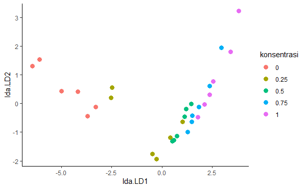

```r
plot_lda_konsen <- data.frame(data[, "konsentrasi"], lda = predict(lda_konsen)$x)

ggplot(plot_lda_konsen) + geom_point(aes(x = lda.LD1, y = lda.LD2, colour = konsentrasi), size = 3) + theme_classic()
```

dari gambar tersebut, variabel Lemak dan Abu lebih memberikan efek yang signifikan (terlihat berbeda) pada eksperimen dengan faktor Konsentrasi yang dibandingkan terhadap Konsentrasi 0.00 dan 0.25 (dot point warna merah dan cokelat cenderung ‘terpisah’ dibandingkan dengan kelompok dot point lainnya)

```r
# faktor waktu
lda_waktu <- lda(data$waktu ~ amatan, CV=F)
lda_waktu
```

```
Call:
lda(data$waktu ~ amatan, CV = F)

Prior probabilities of groups:
       30        60        90
0.3333333 0.3333333 0.3333333

Group means:
   amatan1 amatan2
30   0.630   0.334
60   0.426   0.376
90   0.459   0.331

Coefficients of linear discriminants:
              LD1        LD2
amatan1 -3.211941 -0.4465213
amatan2 -2.704258 -4.4997626

Proportion of trace:
   LD1    LD2
0.9195 0.0805
```

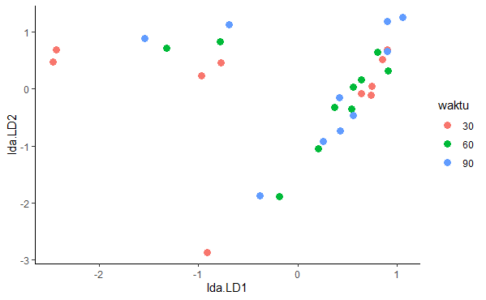

```r
plot_lda_waktu <- data.frame(data[, "waktu"], lda = predict(lda_waktu)$x)

ggplot(plot_lda_waktu) + geom_point(aes(x = lda.LD1, y = lda.LD2, colour = waktu), size = 3) + theme_classic()
```

dari gambar tersebut, tercermin bahwa faktor Waktu terlihat kurang bisa memberikan efek yang signifikan berbeda terhadap variabel dependen. Pada ketiga level waktu, sebaran data tidak menunjukkan diskriminasi atau perbedaan/pengelompokkan yang nyata.

### (6.4) Mean Plot

Untuk lebih dapat menggambarkan hasil pengujian yang telah dilalui, dibentuk visualisasi dalam bentuk Plot Mean untuk setiap variabel dependen.

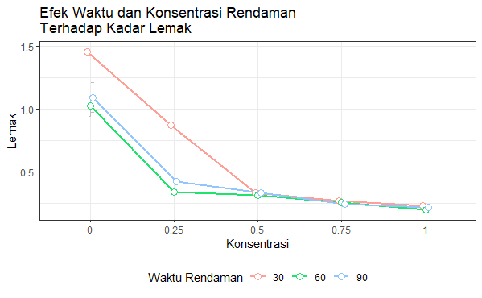

```r
# efek Waktu dan Konsentrasi terhadap Lemak

lemak_se <- summarySE(data, measurevar="lemak", groupvars=c("waktu","konsentrasi"))

ggplot(lemak_se, aes(x=konsentrasi, y=lemak, colour=waktu, group=waktu)) +
  geom_errorbar(aes(ymin=lemak-se, ymax=lemak+se), colour="grey", width=.1, position=position_dodge(0.1)) +
  geom_line(position=position_dodge(0.1), size=1) +
  geom_point(position=position_dodge(0.1), size=3, shape=21, fill="white") +
  xlab("Konsentrasi") + ylab("Lemak") +
  scale_colour_hue(name="Waktu Rendaman",
                   breaks=c("30", "60", "90"),
                   labels=c("30", "60", "90"),l=80) +
  ggtitle("Efek Waktu dan Konsentrasi Rendaman\nTerhadap Kadar Lemak") +
  theme_bw () + theme(legend.justification="center", legend.position="bottom")
```

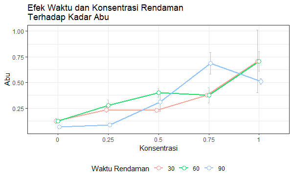

```r
abu_se <- summarySE(data, measurevar="abu", groupvars=c("waktu","konsentrasi"))


ggplot(abu_se, aes(x=konsentrasi, y=abu, colour=waktu, group=waktu)) +
  geom_errorbar(aes(ymin=abu-se, ymax=abu+se), colour="grey", width=.1, position=position_dodge(0.1)) +
  geom_line(position=position_dodge(0.1), size=1) +
  geom_point(position=position_dodge(0.1), size=3, shape=21, fill="white") +
  xlab("Konsentrasi") + ylab("Abu") +
  scale_colour_hue(name="Waktu Rendaman",
                   breaks=c("30", "60", "90"),
                   labels=c("30", "60", "90"),l=80) +
  ggtitle("Efek Waktu dan Konsentrasi Rendaman\nTerhadap Kadar Abu") +
  theme_bw () + theme(legend.justification="center", legend.position="bottom")
```

Grafik tersebut (menghiraukan error bar) mengonfirmasi hasil Manova, bahwa faktor konsentrasi memberikan efek perbedaan (secara visual) yang nyata terhadap kadar Abu. Sedangkan antar ketiga Waktu rendaman memiliki efek yang hampir serupa kecuali untuk waktu rendaman 90.

## Referensi

[1] Aguilar-Trigueros, C. A., & Rillig, M. C. (2016). Effect of different root endophytic fungi on plant community structure in experimental microcosms. *Ecology and Evolution*, 6(22), 8149–8158. https://doi.org/10.1002/ece3.2416

[2] Jarma Arroyo, S. E., Hogan, V., Wisdom, D. A., Moldenhauer, K. A. K., & Seo, H. S. (2020). Effect of geographical indication information on consumer acceptability of cooked aromatic rice. *Foods*, 9(12). https://doi.org/10.3390/foods9121843

[3] Dibaba, F. K., Goro, K. K., Wolide, A. D., Fufa, F. G., Garedow, A. W., Tufa, B. E., & Bobasa, E. M. (2020). Knowledge, attitude and willingness to donate organ among medical students of Jimma University, Jimma Ethiopia: Cross-sectional study. *BMC Public Health*, 20(1). https://doi.org/10.1186/s12889-020-08931-y

[4] Mirmazloum, I., Kiss, A., Erdélyi, É., Ladányi, M., Németh, É. Z., & Radácsi, P. (2020). The effect of osmopriming on seed germination and early seedling characteristics of carum carvi L. *Agriculture (Switzerland)*, 10(4). https://doi.org/10.3390/agriculture10040094

[5] Yoo, S., & Whang, M. (2020). Vagal tone differences in empathy level elicited by different emotions and a co-viewer. *Sensors (Switzerland)*, 20(11). https://doi.org/10.3390/s20113136

[6] Smith, K. N., Lamb, K. N., & Henson, R. K. (2020). Making Meaning out of MANOVA: The Need for Multivariate Post Hoc Testing in Gifted Education Research. *Gifted Child Quarterly*, 64(1), 41–55. https://doi.org/10.1177/0016986219890352

## (8) Appendix

Dari data yang ada digambarkan Histogram sebagai berikut:

##### Histogram Kadar Lemak Berdasarkan Jenis Konsentrasi

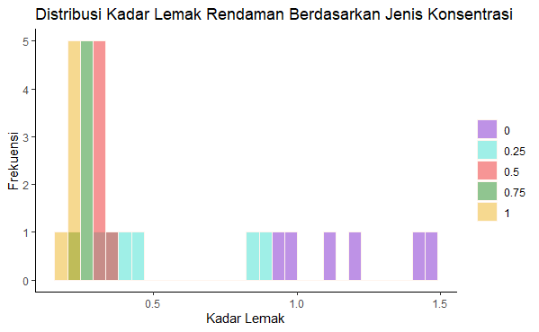

```r
lemak_kon
```

##### Histogram Kadar Abu Berdasarkan Jenis Konsentrasi

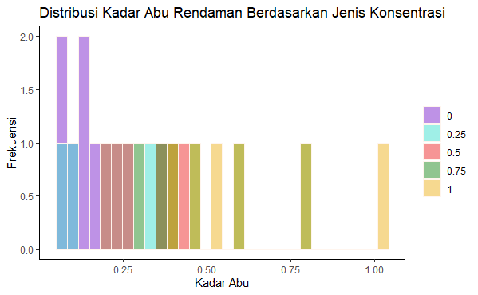

```r
abu_kon <- data %>%
  ggplot( aes(x=abu, fill=konsentrasi)) +
  geom_histogram(color="seashell", alpha=0.5, position = 'identity') +
  scale_fill_manual(values=c("purple3", "turquoise", "firebrick2", "forestgreen", "goldenrod2")) +
  theme_classic() + ggtitle("Distribusi Kadar Abu Rendaman Berdasarkan Jenis Konsentrasi") +
  labs(fill="") + xlab("Kadar Abu") + ylab("Frekuensi")

abu_kon
```

##### Histogram Kadar Lemak Berdasarkan Jenis Waktu

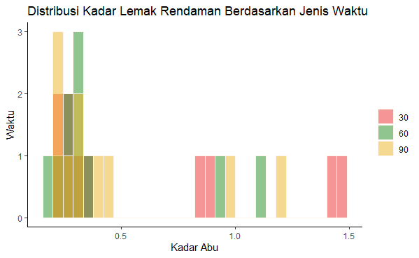

```r
lemak_wa <- data %>%
  ggplot( aes(x=lemak, fill=waktu)) +
  geom_histogram(color="seashell", alpha=0.5, position = 'identity') +
  scale_fill_manual(values=c("firebrick2", "forestgreen", "goldenrod2")) +
  theme_classic() + ggtitle("Distribusi Kadar Lemak Rendaman Berdasarkan Jenis Waktu") +
  labs(fill="") + xlab("Kadar Abu") + ylab("Waktu")

lemak_wa
```

##### Histogram Kadar Abu Berdasarkan Jenis Waktu

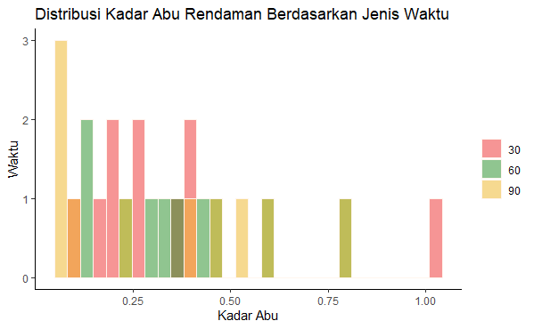

```r
abu_wa <- data %>%
  ggplot( aes(x=abu, fill=waktu)) +
  geom_histogram(color="seashell", alpha=0.5, position = 'identity') +
  scale_fill_manual(values=c("firebrick2", "forestgreen", "goldenrod2")) +
  theme_classic() + ggtitle("Distribusi Kadar Abu Rendaman Berdasarkan Jenis Waktu") +
  labs(fill="") + xlab("Kadar Abu") + ylab("Waktu")

abu_wa
```

##### Histogram Kadar Lemak dan Abu Rendaman Kulit Ikan

```r
hist(data$lemak, col=rgb(0/255,250/255,154/255,0.5),
     xlab="Kandungan (Lemak & Abu)",
     ylab="Frekuensi", border = "gray",
     main="Distribusi Kandungan Lemak dan Abu Kulit Ikan")

hist(data$abu , border = "gray", col=rgb(255/255,215/255,0/255,0.5), add=T)
```

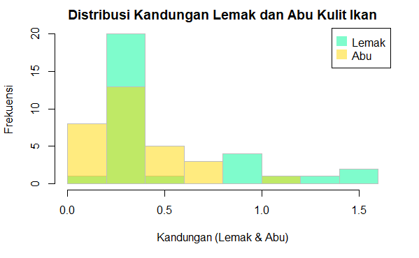

```r
legend("topright", legend=c("Lemak","Abu"),
       col=c(rgb(0/255,250/255,154/255,0.5),
             rgb(255/255,215/255,0/255,0.5)), pt.cex=2, pch=15 )
```